# [Chapter 10] Predicting sale price in Ames using LS

[DSLC stages]: Analysis

The following code sets up the libraries and creates cleaned and pre-processed training, validation and test data that we will use in this document.

```r
# loading libraries
library(tidyverse)
library(janitor)
library(L1pack)
library(lubridate)
library(yardstick)
library(scales)
library(patchwork)
library(fastDummies)
library(glmnet)
# cleaning and pre-processing the Ames data
source("functions/prepareAmesData.R")
# list all objects (and custom functions) that exist in our environment
ls()
```

```
 [1] "ames"                    "ames_orig"
 [3] "ames_test"               "ames_test_clean"
 [5] "ames_test_preprocessed"  "ames_train"
 [7] "ames_train_clean"        "ames_train_preprocessed"
 [9] "ames_val"                "ames_val_clean"
[11] "ames_val_preprocessed"   "cleanAmesData"
[13] "preProcessAmesData"      "split_date"
[15] "train_neighborhoods"
```

## 1 LS with multiple predictors

First, let’s fit the four-predictor version of the LS fit.

```r
ls_multi4 <- lm(sale_price ~ gr_liv_area + year_built + overall_qual + bedroom_abv_gr,
                ames_train_preprocessed)

ls_multi4
```

```
Call:
lm(formula = sale_price ~ gr_liv_area + year_built + overall_qual +
    bedroom_abv_gr, data = ames_train_preprocessed)

Coefficients:
   (Intercept)     gr_liv_area      year_built    overall_qual  bedroom_abv_gr
    -871630.49           87.66          426.24        19129.24       -12667.47
```

### 1.1 Comparing coefficients

Comparing the coefficients using the *theoretical* $t$-values can be done by applying the `summary()` function to the `ls_multi4` object (look at the `t value` column):

```r
summary(ls_multi4)
```

```
Call:
lm(formula = sale_price ~ gr_liv_area + year_built + overall_qual +
    bedroom_abv_gr, data = ames_train_preprocessed)

Residuals:
   Min     1Q Median     3Q    Max
-98276 -18988   -531  17494 257735

Coefficients:
                 Estimate Std. Error t value Pr(>|t|)
(Intercept)    -871630.49   70885.12 -12.296   <2e-16 ***
gr_liv_area         87.66       2.84  30.862   <2e-16 ***
year_built         426.24      37.12  11.483   <2e-16 ***
overall_qual     19129.24    1042.25  18.354   <2e-16 ***
bedroom_abv_gr  -12667.47    1455.14  -8.705   <2e-16 ***
---
Signif. codes:  0 '***' 0.001 '**' 0.01 '*' 0.05 '.' 0.1 ' ' 1

Residual standard error: 31230 on 1121 degrees of freedom
Multiple R-squared:  0.8038,    Adjusted R-squared:  0.8031
F-statistic:  1148 on 4 and 1121 DF,  p-value: < 2.2e-16
```

However, in veridical data science we prefer to empirically estimate the standard deviation of the coefficients in order to compute the t-values, where $t_j = b_j / SD(b_j)$, e.g., using the bootstrap.

The following code uses the bootstrap (sampling with replacement) to create 1000 different perturbed versions of the data, computes a LS fit for each bootstrap sample, and reports the bootstrap coefficients in a nice tidy data frame (tibble):

```r
set.seed(2678)
boot_coefs <- map_df(1:1000, function(i) {
  # compute a bootstrap sample
  ames_boot <- ames_train_preprocessed |>
    sample_frac(1, replace = TRUE)
  # fit LS
  ls_multi4_boot <- lm(sale_price ~ gr_liv_area + year_built +
                         overall_qual + bedroom_abv_gr,
                       ames_boot)
  # return the results in a nice data frame
  return(enframe(ls_multi4_boot$coefficients,
                 name = "variable",
                 value = "coefficient"))
}, .id = "boot")

boot_coefs
```

```
# A tibble: 5,000 × 3
   boot  variable       coefficient
   <chr> <chr>                <dbl>
 1 1     (Intercept)      -954451.
 2 1     gr_liv_area           87.5
 3 1     year_built           474.
 4 1     overall_qual       17781.
 5 1     bedroom_abv_gr    -13687.
 6 2     (Intercept)     -1060102.
 7 2     gr_liv_area           84.5
 8 2     year_built           526.
 9 2     overall_qual       17925.
10 2     bedroom_abv_gr    -10995.
# ℹ 4,990 more rows
```

Then we can compute the standard deviation of each of the bootstrap coefficients, and use these standard deviation estimates to compute the standardized coefficients.

```r
boot_coefs |>
  # compute the bootstrapped SD for each coefficient
  group_by(variable) |>
  summarise(sd = sd(coefficient)) |>
  ungroup() |>
  # add the original coefficients
  left_join(enframe(ls_multi4$coefficients,
                    name = "variable",
                    value = "coefficient"),
            by = "variable") |>
  # compute the standardized coefficient
  mutate(standardized_coefficient = coefficient / sd)
```

```
# A tibble: 5 × 4
  variable             sd coefficient standardized_coefficient
  <chr>             <dbl>       <dbl>                    <dbl>
1 (Intercept)    72723.     -871630.                    -12.0
2 bedroom_abv_gr  2076.      -12667.                     -6.10
3 gr_liv_area        5.57        87.7                    15.8
4 overall_qual    1229.       19129.                     15.6
5 year_built        38.4        426.                     11.1
```

## 2 Pre-processing: one-hot encoding

To create one-hot encoded binary (dummy) variables, you can either do it “manually” (e.g., using `muate()`) or you can use the `dummy_cols()` function from the fastDummies R package.

If the original “clean” (but not pre-processed) data looks like this:

```r
head(ames_train_clean)
```

```
  order       pid ms_sub_class ms_zoning lot_frontage lot_area street alley
1   990 526351030           20        RL           87    11029   Pave  <NA>
2   991 526353050           20        RL           NA    12925   Pave  <NA>
3   992 526354070           60        RL           85    11075   Pave  <NA>
4   993 527105050           60        RL           72     8702   Pave  <NA>
5   995 527106140           60        RL           59     9535   Pave  <NA>
6   996 527106150           60        RL           59     9042   Pave  <NA>
  lot_shape land_contour utilities lot_config land_slope neighborhood
1       IR1          Lvl    AllPub     Corner        Gtl        NAmes
2       IR1          Lvl    AllPub     Corner        Gtl        NAmes
3       Reg          Lvl    AllPub     Inside        Gtl        NAmes
4       IR1          Lvl    AllPub     Inside        Gtl      Gilbert
5       IR1          Lvl    AllPub     Inside        Gtl      Gilbert
6       IR1          Lvl    AllPub     Inside        Gtl      Gilbert
  condition_1 condition_2 bldg_type house_style overall_qual overall_cond
```

[output cut: 83 more lines]

Then the version with dummy variables for the specified columns looks like this (the binary dummy variable columns are placed at the end):

```r
# identify factor columns
fct_vars <- ames_train_clean |>
  select(where(is.factor)) |>
  colnames()
# create dummy columns
ames_train_clean |>
  dummy_cols(select_columns = fct_vars,
             remove_first_dummy = TRUE,
             remove_selected_columns = TRUE) |>
  head()
```

```
  order       pid ms_sub_class lot_frontage lot_area overall_qual overall_cond
1   990 526351030           20           87    11029            6            8
2   991 526353050           20           NA    12925            6            7
3   992 526354070           60           85    11075            6            5
4   993 527105050           60           72     8702            6            5
5   995 527106140           60           59     9535            6            5
6   996 527106150           60           59     9042            6            5
  year_built year_remod_add mas_vnr_area bsmt_fin_sf_1 bsmt_fin_sf_2
1       1958           2002            0           528           411
2       1970           1970            0           865             0
3       1969           1969            0           500           276
4       1997           1998            0           706             0
5       1998           1998            0           851             0
6       1998           1998            0           828             0
  bsmt_unf_sf total_bsmt_sf x1st_flr_sf x2nd_flr_sf low_qual_fin_sf gr_liv_area
```

[output cut: 412 more lines]

The `remove_first_dummy = TRUE` argument specifies that the first level of the factor variable will be the reference level and no binary variable is created for it.

We included code for creating dummy variables in the `functions/preProcessAmesData.R` file. (Some variables are manually converted to binary dummy variables, and others are converted using `dummy_cols()`.)

We could then include these dummy variables in a `lm()` fit, but it is helpful to note that `lm()` will actually create these dummy variables for you if you provide a categorical feature.

For example:

```r
lm(sale_price ~ gr_liv_area + year_built +
     overall_qual + bedroom_abv_gr +
     neighborhood,
   data = ames_train_clean)
```

```
Call:
lm(formula = sale_price ~ gr_liv_area + year_built + overall_qual +
    bedroom_abv_gr + neighborhood, data = ames_train_clean)

Coefficients:
        (Intercept)          gr_liv_area           year_built
         -597245.91                77.89               294.99
       overall_qual       bedroom_abv_gr  neighborhoodBlueste
           16272.63            -10253.40             -6236.65
 neighborhoodBrDale  neighborhoodBrkSide  neighborhoodClearCr
          -33286.59              1768.42             25646.01
neighborhoodCollgCr  neighborhoodCrawfor  neighborhoodEdwards
           10628.49             21831.73             -1807.80
neighborhoodGilbert   neighborhoodGreens   neighborhoodIDOTRR
           -4473.21             -6540.07             -6432.05
neighborhoodLandmrk  neighborhoodMeadowV  neighborhoodMitchel
          -23357.90            -18452.10             12832.02
  neighborhoodNAmes  neighborhoodNoRidge  neighborhoodNPkVill
            8637.51             63752.35            -14903.73
neighborhoodNridgHt   neighborhoodNWAmes  neighborhoodOldTown
           51242.65              2826.37             -8421.53
 neighborhoodSawyer  neighborhoodSawyerW  neighborhoodSomerst
           11951.88                28.96              6396.83
neighborhoodStoneBr    neighborhoodSWISU   neighborhoodTimber
           62012.07            -12869.24             26613.87
neighborhoodVeenker
           40751.96
```

## 3 LS with all predictive features

If you have a lot of predictive features and you want to include all of them in your linear fit, fortunately you don’t have to manually write out the name of each variable in your `lm()` function, because you can use the `.` short-hand notation. The following code uses all (pre-processed) predictive features to compute a LS fit for sale price:

```r
ls_all <- lm(sale_price ~ ., ames_train_preprocessed)
ls_all
```

```
Call:
lm(formula = sale_price ~ ., data = ames_train_preprocessed)

Coefficients:
             (Intercept)              lot_frontage                  lot_area
              -8.417e+05                 2.474e+02                 3.516e-01
            overall_qual              overall_cond                year_built
               1.088e+04                 5.598e+03                 2.557e+02
          year_remod_add              mas_vnr_area                exter_qual
               3.712e+01                 5.471e+01                 6.214e+03
               bsmt_qual             bsmt_exposure             total_bsmt_sf
              -1.556e+03                 5.375e+03                 2.162e+01
              heating_qc               gr_liv_area            bedroom_abv_gr
               2.316e+03                 6.520e+01                -6.073e+03
            kitchen_qual           tot_rms_abv_grd                fireplaces
               5.571e+03                -9.309e+02                 4.267e+03
            fireplace_qu             garage_yr_blt             garage_finish
              -2.641e+02                -6.476e+01                 1.650e+03
             garage_cars               garage_area              wood_deck_sf
              -1.507e+02                 2.287e+01                 4.809e+00
                 mo_sold                   yr_sold      masonry_veneer_brick
               3.132e+02                 1.489e+02                -1.101e+04
       foundation_cinder       foundation_concrete           garage_attached
              -6.835e+03                 3.316e+03                -3.777e+03
              lot_inside            exterior_vinyl                 bathrooms
               3.344e+03                -3.066e+03                 3.558e+03
                   porch       residential_density       irregular_lot_shape
              -2.449e+03                -9.903e+03                 3.312e+03
            house_floors  basement_finished_rating        neighborhood_NAmes
              -6.063e+03                 1.678e+03                -4.829e+03
    neighborhood_Gilbert       neighborhood_NWAmes      neighborhood_Somerst
              -9.572e+03                -1.267e+04                -2.000e+04
     neighborhood_Sawyer      neighborhood_BrkSide      neighborhood_OldTown
              -4.904e+03                 4.079e+03                -7.068e+03
    neighborhood_Edwards      neighborhood_CollgCr      neighborhood_Mitchel
              -9.859e+03                -1.110e+04                -9.112e+03
```

## 4 Feature selection

Identifying which variables are highly correlated with the response can be done using the `cor()` function:

```r
cor_sale_price <- ames_train_preprocessed |>
  # select just the numeric columns
  select(where(is.numeric)) |>
  # compute the correlation matrix
  cor() |>
  # convert the cor matrix to a tibble and add a "variable" column that
  # contains the variable rownames
  as_tibble(rownames = "variable") |>
  # select just the sale price correlation column
  select(variable, cor_sale_price = sale_price) |>
  # remove the correlation of sale price with itself
  filter(variable != "sale_price") |>
  # arrange in descending (absolute value) order
  arrange(desc(abs(cor_sale_price)))
cor_sale_price
```

```
# A tibble: 47 × 2
   variable        cor_sale_price
   <chr>                    <dbl>
 1 overall_qual             0.776
 2 gr_liv_area              0.775
 3 bathrooms                0.668
 4 exter_qual               0.628
 5 kitchen_qual             0.624
 6 total_bsmt_sf            0.614
 7 garage_cars              0.608
 8 garage_area              0.597
 9 tot_rms_abv_grd          0.531
10 bsmt_qual                0.528
# ℹ 37 more rows
```

We can count how many are greater than 0.5:

```r
cor_select <- cor_sale_price |>
  filter(cor_sale_price >= 0.5)
cor_select
```

```
# A tibble: 13 × 2
   variable        cor_sale_price
   <chr>                    <dbl>
 1 overall_qual             0.776
 2 gr_liv_area              0.775
 3 bathrooms                0.668
 4 exter_qual               0.628
 5 kitchen_qual             0.624
 6 total_bsmt_sf            0.614
 7 garage_cars              0.608
 8 garage_area              0.597
 9 tot_rms_abv_grd          0.531
10 bsmt_qual                0.528
11 mas_vnr_area             0.526
12 fireplace_qu             0.506
13 garage_finish            0.500
```

Which shows that 13 of the correlations are greater than (or equal to) 0.5.

You could train a LS fit just using these features as follows:

```r
ls_cor <- lm(sale_price ~ .,
             data = select(ames_train_preprocessed,
                           sale_price, cor_select$variable))
ls_cor
```

```
Call:
lm(formula = sale_price ~ ., data = select(ames_train_preprocessed,
    sale_price, cor_select$variable))

Coefficients:
    (Intercept)     overall_qual      gr_liv_area        bathrooms
      -96674.56         11367.66            59.92          8074.96
     exter_qual     kitchen_qual    total_bsmt_sf      garage_cars
        7994.85         12794.64            33.62         -1539.02
    garage_area  tot_rms_abv_grd        bsmt_qual     mas_vnr_area
          32.61         -4548.00          -896.47            45.03
   fireplace_qu    garage_finish
        1721.57          3482.22
```

## 5 Ridge and lasso

### 5.1 Choosing $\lambda$ using cross-validation

Using 10-fold cross-validation to choose the ridge hyperparameter can be done using the `cv.glmnet()` function from the glmnet R package.

The glmnet package functions all require matrix inputs, so we first need to create those:

```r
x <- ames_train_preprocessed |>
  dplyr::select(-sale_price) |>
  # standardize the features
  mutate_all(~(. - mean(.)) / sd(.)) |>
  as.matrix()
y <- ames_train_preprocessed |>
  pull(sale_price)
```

Then we can use the `cv.glmnet()` function (`alpha = 0` corresponds to ridge, whereas `alpha = 1` corresponds to lasso) to identify reasonable hyperparameter values

```r
set.seed(4848)
ridge_cv <- cv.glmnet(x = x, y = y,
                      type.measure="mse",
                      nfolds = 10,
                      alpha = 0)

lasso_cv <- cv.glmnet(x = x, y = y,
                      type.measure="mse",
                      nfolds = 10,
                      alpha = 1)
```

This is the sequence of $\lambda$ values used for ridge

```r
ridge_cv$lambda
```

```
  [1] 54575196.342 49726886.315 45309286.788 41284134.627 37616565.891
  [6] 34274813.852 31229933.855 28455552.605 25927639.738 23624299.683
 [11] 21525582.011 19613308.632 17870916.350 16283313.395 14836748.712
 [16] 13518692.848 12317729.435 11223456.301 10226395.376  9317910.596
 [21]  8490133.100  7735893.075  7048657.655  6422474.336  5851919.417
 [26]  5332051.025  4858366.308  4426762.435  4033501.061  3675175.943
 [31]  3348683.442  3051195.634  2780135.824  2533156.219  2308117.602
 [36]  2103070.796  1916239.783  1746006.322  1590895.933  1449565.123
 [41]  1320789.752  1203454.431  1096542.856   999129.011   910369.143
 [46]   829494.458   755804.456   688660.871   627482.138   571738.354
 [51]   520946.694   474667.226   432499.098   394077.070   359068.349
 [56]   327169.707   298104.852   271622.038   247491.885   225505.388
 [61]   205472.111   187218.535   170586.556   155432.117   141623.956
 [66]   129042.474   117578.696   107133.329    97615.899    88943.972
 [71]    81042.434    73842.848    67282.853    61305.630    55859.406
 [76]    50897.011    46375.461    42255.593    38501.722    35081.335
 [81]    31964.806    29125.141    26537.744    24180.204    22032.101
 [86]    20074.830    18291.437    16666.476    15185.873    13836.802
 [91]    12607.578    11487.556    10467.033     9537.171     8689.915
 [96]     7917.927     7214.520     6573.602     5989.621     5457.520
```

and the $\lambda.min$ (value that yielded the smallest MSE) is

```r
ridge_cv$lambda.min
```

```
[1] 5457.52
```

which is the smallest $\lambda$ value (this often happens), which is why we actually tend to use $\lambda_{1SE}$ (the largest value of $\lambda$ such that the MSE is within one standard error of the minimum):

```r
ridge_cv$lambda.1se
```

```
[1] 38501.72
```

Similarly for the lasso:

```r
lasso_cv$lambda.1se
```

```
[1] 1320.79
```

(Note that in the book, we reported the logarithm of these values).

We can visualize the results for each $\lambda$ in the following plots:

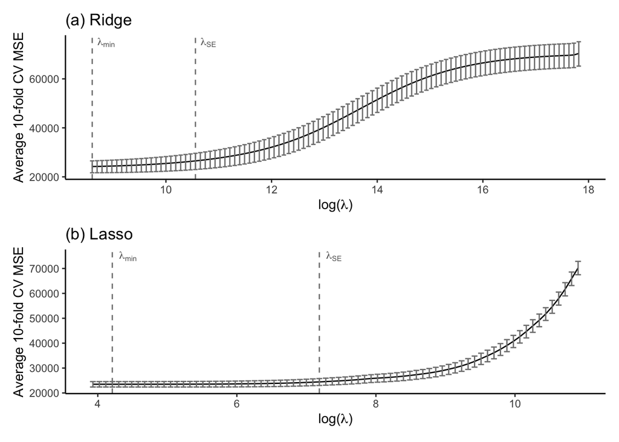

```r
gg_ridge_cv <- data.frame(lambda = ridge_cv$glmnet.fit$lambda,
                          mse = sqrt(ridge_cv$cvm),
                          mse_upper = sqrt(ridge_cv$cvup),
                          mse_lower = sqrt(ridge_cv$cvlo)) |>
  ggplot() +
  geom_line(aes(x = log(lambda), y = mse)) +
  geom_errorbar(aes(x = log(lambda), ymax = mse_upper, ymin = mse_lower),
                color = "grey50") +
  geom_vline(xintercept = log(ridge_cv$lambda.min), linetype = "dashed",
             color = "grey50") +
  geom_vline(xintercept = log(ridge_cv$lambda.1se), linetype = "dashed",
             color = "grey50") +
  geom_text(aes(x = x, y = y, label = label),
            data = data.frame(x = log(ridge_cv$lambda.min) + 0.1,
                              y = 75000,
                              label = "lambda[min]"),
            col = "grey40", size = 3, hjust = 0, parse = T) +
  geom_text(aes(x = x, y = y, label = label),
            data = data.frame(x = log(ridge_cv$lambda.1se) + 0.1,
                              y = 75000,
                              label = "lambda[SE]"),
            col = "grey40", size = 3, hjust = 0, parse = T) +
  theme_classic() +
  labs(y = "Average 10-fold CV MSE", title = "(a) Ridge",
       x = expression(paste('log(', lambda, ")")))

gg_lasso_cv <- data.frame(lambda = lasso_cv$glmnet.fit$lambda,
                          mse = sqrt(lasso_cv$cvm),
                          mse_upper = sqrt(lasso_cv$cvup),
                          mse_lower = sqrt(lasso_cv$cvlo)) |>
  ggplot() +
  geom_line(aes(x = log(lambda), y = mse)) +
  geom_errorbar(aes(x = log(lambda), ymax = mse_upper, ymin = mse_lower),
                color = "grey50") +
  geom_vline(xintercept = log(lasso_cv$lambda.min), linetype = "dashed",
             color = "grey50") +
  geom_vline(xintercept = log(lasso_cv$lambda.1se), linetype = "dashed",
             color = "grey50") +
  geom_text(aes(x = x, y = y, label = label),
            data = data.frame(x = log(lasso_cv$lambda.min) + 0.1,
                              y = 75000,
                              label = "lambda[min]"),
            col = "grey40", size = 3, hjust = 0, parse = T) +
  geom_text(aes(x = x, y = y, label = label),
            data = data.frame(x = log(lasso_cv$lambda.1se) + 0.1,
                              y = 75000,
                              label = "lambda[SE]"),
            col = "grey40", size = 3, hjust = 0, parse = T) +
  theme_classic() +
  labs(y = "Average 10-fold CV MSE", title = "(b) Lasso",
       x = expression(paste('log(', lambda, ")")))

# align the plots in two rows using patchwork syntax
gg_ridge_cv / gg_lasso_cv
```

### 5.2 Fitting ridge and lasso models

Having chosen the $\lambda$ values for ridge and lasso using CV, we can fit the ridge and lasso models.

Note that the syntax is a bit different from `lm()`. Moreover, rather than providing just the selected $\lambda$ value, it is recommended to provide the entire sequence of $\lambda$ values (which will create a fit for each $\lambda$ value provided), and then extract the fit for the relevant lambdas.

```r
# train the lasso fits for a sequence of lambdas
lasso_fit <- glmnet(x = x, y = y, lambda = lasso_cv$lambda, alpha = 1)
# identify which fits correspond to the relevant lambda values
lasso_lambda_min_index <- which(lasso_fit$lambda == lasso_cv$lambda.min)
lasso_lambda_1se_index <- which(lasso_fit$lambda == lasso_cv$lambda.1se)
```

To view the coefficients, you can extract the relevant column from the `beta` object from the lasso glmnet object. The lasso fit for the $\lambda_{1SE}$ hyperparameter is thus:

```r
lasso_fit$beta[, lasso_lambda_1se_index]
```

```
            lot_frontage                 lot_area             overall_qual
               3832.3132                2133.9179               13952.1986
            overall_cond               year_built           year_remod_add
               3381.1204                 823.9322                 712.7036
            mas_vnr_area               exter_qual                bsmt_qual
               7441.3338                3765.2636                   0.0000
           bsmt_exposure            total_bsmt_sf               heating_qc
               5522.8934                9288.1623                1724.7477
             gr_liv_area           bedroom_abv_gr             kitchen_qual
              28093.4127               -3426.9618                4839.6290
         tot_rms_abv_grd               fireplaces             fireplace_qu
                  0.0000                2372.2450                   0.0000
           garage_yr_blt            garage_finish              garage_cars
                  0.0000                 735.5618                   0.0000
             garage_area             wood_deck_sf                  mo_sold
               4142.1138                 570.3381                   0.0000
                 yr_sold     masonry_veneer_brick        foundation_cinder
                  0.0000               -1222.9915               -1100.5508
     foundation_concrete          garage_attached               lot_inside
                958.8841                   0.0000                   0.0000
          exterior_vinyl                bathrooms                    porch
                  0.0000                2864.1562                   0.0000
     residential_density      irregular_lot_shape             house_floors
              -1731.1310                1412.9938                -320.5133
basement_finished_rating       neighborhood_NAmes     neighborhood_Gilbert
               2851.6070                   0.0000                   0.0000
     neighborhood_NWAmes     neighborhood_Somerst      neighborhood_Sawyer
               -848.9775                   0.0000                   0.0000
    neighborhood_BrkSide     neighborhood_OldTown     neighborhood_Edwards
                  0.0000               -1558.7721                   0.0000
    neighborhood_CollgCr     neighborhood_Mitchel
                  0.0000                   0.0000
```

Notice that several of the variables coefficients are exactly equal to 0!

Predictions can be generated using the same `predict()` function as before. For instance, below we compute the predictions for the lasso fit using the $\lambda_{1SE}$ hyperparameter using the *training data*.

```r
predict(lasso_fit, x)[, lasso_lambda_1se_index]
```

```
   [1] 196287.08 219471.35 205940.03 176055.02 190291.40 201764.84 248869.37
   [8] 179539.64 178068.72 229021.42 310703.08 294612.84 166945.29 292589.75
  [15] 244922.00 190879.84 190613.28 234565.17 273892.50 207662.44 124696.62
  [22] 167318.57 283061.50 155991.35 144798.46 105130.05  95155.26 106861.21
  [29] 115916.00 141566.54 341508.26 387781.03 265684.40 286728.18 415474.75
  [36] 370975.37 273620.45 355108.53 328163.13 231232.26 281946.50 294181.82
  [43] 218139.94 214428.22 217934.66 217103.59 202464.43 189521.84 180684.04
  [50] 178145.46 203845.91 159498.15 202309.54 219488.89 202851.54 249243.05
  [57] 209388.36 179186.98 231330.65 185101.39 306781.31 287992.23 324605.34
  [64] 249914.02 303231.80 269558.18 219912.15 238719.18 228104.80 259797.59
  [71] 213114.37 236927.96 200724.31 259406.11 201245.62 154387.19 202410.88
  [78] 206719.01 153080.86 149959.54 158951.43 180851.27 185529.01 207298.83
  [85] 169292.89 199108.47 206968.05 172661.30 131671.24 110607.78 146522.36
  [92] 194695.30 146118.05 267368.78 358555.52 213914.68 171373.54 192449.54
  [99] 160099.27 167413.72 283516.39 249115.44 269180.03 172920.11 184068.03
```

[output cut: 146 more lines]

We have just shown the code for lasso fit, but the ridge fit is equivalent (you just need to change the `glmnet()` argument to `alpha = 0`):

```r
# train the lasso fits for a sequence of lambdas
ridge_fit <- glmnet(x = x, y = y, lambda = ridge_cv$lambda, alpha = 0)
# identify which fits correspond to the relevant lambda values
ridge_lambda_min_index <- which(ridge_fit$lambda == ridge_cv$lambda.min)
ridge_lambda_1se_index <- which(ridge_fit$lambda == ridge_cv$lambda.1se)
```

```r
ridge_fit$beta[, ridge_lambda_1se_index]
```

```
            lot_frontage                 lot_area             overall_qual
               4440.6241                3230.1954                9119.5234
            overall_cond               year_built           year_remod_add
               3268.9022                1253.5535                1886.1267
            mas_vnr_area               exter_qual                bsmt_qual
               6930.2190                4735.7436                1486.9123
           bsmt_exposure            total_bsmt_sf               heating_qc
               4490.2175                7686.0286                2620.2239
             gr_liv_area           bedroom_abv_gr             kitchen_qual
              12088.3588                -430.1839                5102.3502
         tot_rms_abv_grd               fireplaces             fireplace_qu
               4370.6934                3656.5496                2819.9027
           garage_yr_blt            garage_finish              garage_cars
                721.5729                1705.8358                2708.1001
             garage_area             wood_deck_sf                  mo_sold
               3987.9659                1928.4411                 -60.8743
                 yr_sold     masonry_veneer_brick        foundation_cinder
                307.4512                -901.6486               -2028.2006
     foundation_concrete          garage_attached               lot_inside
               1727.8349                 493.2098                 316.0147
          exterior_vinyl                bathrooms                    porch
               -652.3500                5006.5863                 334.6941
     residential_density      irregular_lot_shape             house_floors
              -2349.4318                2089.4333                 806.7958
basement_finished_rating       neighborhood_NAmes     neighborhood_Gilbert
               2454.2076               -1206.5470               -2094.8858
     neighborhood_NWAmes     neighborhood_Somerst      neighborhood_Sawyer
              -1631.6026               -1193.1497                -997.5220
    neighborhood_BrkSide     neighborhood_OldTown     neighborhood_Edwards
                418.3051               -1217.6663               -1316.6102
    neighborhood_CollgCr     neighborhood_Mitchel
              -1859.5973               -1140.2472
```

### 5.3 Exploring coefficient shrinkage

Let’s visualize how much each regularization algorithm shrinks each coefficient.

To do that, we need to extract the coefficients from each regularized fit, as well as the original fit with all features.

First, we will re-compute the original fit using standardized variables so that the coefficients are comparable to the ridge and lasso coefficients):

```r
# create a standardized version of the pre-processed training data
ames_train_preprocessed_std <- ames_train_preprocessed |>
  dplyr::select(-sale_price) |>
  mutate_all(~(. - mean(.)) / sd(.)) |>
  mutate(sale_price = ames_train_preprocessed$sale_price)

# compute an unregularized fit
ls_all_std <- lm(sale_price ~ ., ames_train_preprocessed_std)
# extract the coefficients
ls_coefs <- ls_all_std$coefficients[-1] |>
  enframe(name = "variable", value = "coefficient")
```

Then we can extract the coefficients from each of the regularized fits

```r
# lasso lambda_min
ls_lasso_min_coefs <- lasso_fit$beta[, lasso_lambda_min_index] |>
  enframe(name = "variable", value = "coefficient") |>
  mutate(algorithm = "Lasso with min")
# lasso lambda_1se
ls_lasso_1se_coefs <- lasso_fit$beta[, lasso_lambda_1se_index] |>
  enframe(name = "variable", value = "coefficient") |>
  mutate(algorithm = "Lasso with 1SE")
# ridge lambda_min
ls_ridge_min_coefs <- ridge_fit$beta[, ridge_lambda_min_index] |>
  enframe(name = "variable", value = "coefficient") |>
  mutate(algorithm = "Ridge with min")
# ridge lambda_1se
ls_ridge_1se_coefs <- ridge_fit$beta[, ridge_lambda_1se_index] |>
  enframe(name = "variable", value = "coefficient") |>
  mutate(algorithm = "Ridge with 1SE")

# compute the order of the coefficients in terms of absolute value magnitude
order <- rank(abs(ls_coefs$coefficient))
# combine the coefficient tables together
coefs_ls <- mutate(ls_coefs, order = order)
coefs_reg <- mutate(ls_lasso_min_coefs, order = order) |>
  add_row(mutate(ls_lasso_1se_coefs, order = order)) |>
  add_row(mutate(ls_ridge_min_coefs, order = order)) |>
  add_row(mutate(ls_ridge_1se_coefs, order = order))
```

Then can create a plot that compares the unregularized and regularized coefficients for each regularized fit.

Figure Figure 1 shows that the lasso fit with $\lambda_{min}$ implemented almost no shrinkage (implying that this regularization parameter was not large enough to actually perform any meaningful regularization). The ridge fit with $\lambda_{min}$ involves slightly more regularization than the corresponding lasso fit with $\lambda_{min}$, but most of the coeﬀicients are still very similar to their unregularized counterparts. On the other hand, the Lasso fit with $\lambda_{1SE}$ shrank 19 of the 47 coeﬀicients completely to zero (each coeﬀicient that is exactly equal to zero is represented with an $\times$ rather than a point). Note, however, that many of the coeﬀicients of the ridge-regularized fit with $\lambda_{1SE}$ have been shrunk towards zero, but none of the ridge-regularized coefficients are exactly equal to zero.

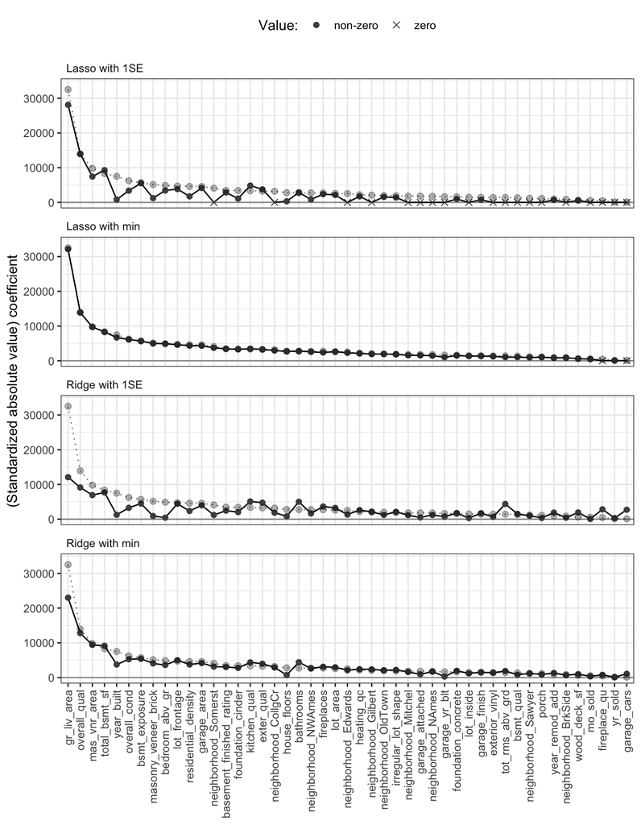

```r
coefs_reg |>
  # make sure the variables appear in the correct order
  arrange(desc(order)) |>
  mutate(variable = fct_inorder(variable)) |>
  arrange(algorithm) |>
  mutate(algorithm = fct_inorder(algorithm)) |>
  # create an indicator for whether each coefficient equals zero
  mutate(zero = coefficient == 0) |>
  ggplot() +
  geom_hline(yintercept = 0, col = "grey60") +
  geom_line(aes(x = variable, y = abs(coefficient), group = algorithm)) +
  # add the unregularized coefficient line
  geom_line(aes(x = variable, y = abs(coefficient), group = 1),
            data = coefs_ls, linetype = "dotted", alpha = 0.5) +
  # add points
  geom_point(aes(x = variable, y = abs(coefficient), shape = zero),
             color = "grey30", size = 2) +
  # add points for unregularized line
  geom_point(aes(x = variable, y = abs(coefficient)),
             data = coefs_ls, alpha = 0.3, size = 2) +
  scale_y_continuous("(Standardized absolute value) coefficient",
                     limits = c(0, 34000)) +
  scale_x_discrete(NULL) +
  scale_alpha_manual("Fit:", values = c(0.3, 1)) +
  scale_shape_manual("Value:", values = c(16, 4), labels = c("non-zero", "zero")) +
  scale_linetype_manual("Fit:", values = c("dotted", "solid")) +
  theme_bw() +
  theme(axis.text.x = element_text(angle = 90, hjust = 1, vjust = 0.5),
        axis.line.x = element_blank(),
        legend.position = "top",
        strip.background = element_blank(),
        strip.text = element_text(hjust = 0)) +
  facet_wrap(~algorithm, nrow = 4)
```

## 6 PCS evaluations

### 6.1 Predictability

Let’s compare the performance of each fit on the validation set houses.

To recap which model is which, we will re-fit them. Since we want to include the neighborhood variable in the multi-predictor fit, so that we don’t have to manually write the names of all of the neighborhood dummy variables, we will create a version of the pre-processed datasets with the neighborhood categorical variable. Note that we have to do some finagling to make sure that the validation set neighborhood levels match those of the training set.

```r
# let's create a version of the pre-processed training data with the
# (non-dummy) categorical neighborhood variable
ames_train_preprocessed_nbhd <- preProcessAmesData(ames_train_clean,
                                                   neighborhood_dummy = FALSE)
# identify which neighborhoods are included in the training data
train_neighborhoods <- ames_train_preprocessed_nbhd |>
  pull(neighborhood) |>
  unique()
# create preprocessed validation set with the non-dummy neighborhood var
ames_val_preprocessed_nbhd <-
  preProcessAmesData(ames_val_clean,
                     neighborhood_dummy = FALSE,
                     column_selection = colnames(ames_train_preprocessed_nbhd),
                     neighborhood_levels = train_neighborhoods)
```

We also need to create a matrix version of the validation set for fitting ridge and lasso. However, note that we will use the mean and SD from the training set to standardize the validation set (the logic here is that if we were using these algorithm to predict the response of a new data point, we would use the training data mean and SD to standardize it).

```r
# standardize the validation set using the mean and SD from the training data
ames_val_preprocessed_std <- map2_df(select(ames_val_preprocessed, -pid, -sale_price),
                                     select(ames_train_preprocessed, -sale_price),
                                     function(.x_val, .x_train) {
                                       (.x_val - mean(.x_train)) / sd(.x_train)
                                     })
x_val <- as.matrix(ames_val_preprocessed_std)
```

Finally we are ready to re-fit our multi-predictor algorithm to include the neighborhood feature:

```r
ls_area <- lm(sale_price ~ gr_liv_area, ames_train_preprocessed)
ls_multi <- lm(sale_price ~ gr_liv_area + overall_qual + bedroom_abv_gr +
                 year_built + neighborhood, ames_train_preprocessed_nbhd)
```

And we can compute predictions for each fit

```r
val_performance <-
  tibble(pid = ames_val_preprocessed$pid,
         true = ames_val_preprocessed$sale_price,
         pred_ls_area = predict(ls_area, ames_val_preprocessed),
         pred_ls_multi = predict(ls_multi, ames_val_preprocessed_nbhd),
         pred_ls_all = predict(ls_all, ames_val_preprocessed),
         pred_ridge = predict(ridge_fit, x_val)[, ridge_lambda_1se_index],
         pred_lasso = predict(lasso_fit, x_val)[, lasso_lambda_1se_index])
```

And we can evaluate the performance of each fit, and format the results in the table below:

```r
val_performance |>
  pivot_longer(c("pred_ls_area", "pred_ls_multi", "pred_ls_all", "pred_ridge", "pred_lasso"),
               names_to = "fit", values_to = "pred") |>
  group_by(fit) |>
  summarise(rmse = rmse_vec(true, pred),
            mae = mae_vec(true, pred),
            cor = cor(true, pred)) |>
  arrange(cor)
```

```
# A tibble: 5 × 4
  fit             rmse    mae   cor
  <chr>          <dbl>  <dbl> <dbl>
1 pred_ls_area  49377. 34714. 0.696
2 pred_ls_multi 31773. 23858. 0.887
3 pred_ridge    23607. 16901. 0.940
4 pred_lasso    23219. 16725. 0.941
5 pred_ls_all   23267. 17332. 0.942
```

Note that the three fits with all of the predictors (`ls_all`, `ridge_fit`, and `lasso_fit`) all have fairly similar (and fairly good, in terms of correlation) predictive performance.

### 6.2 Stability

#### Stability to data perturbations

To assess the stability of our data to appropriate perturbations in the data, we first need to decide what makes an “appropriate” perturbation. That is, what type of data perturbation (e.g., adding random noise, or performing sampling) most resembles the way that the data *could* have been measured or collected differently, as well as how these results will be applied in the future.

While the Ames housing data does not correspond to a random sample from a greater population of houses, each house is more-or-less exchangeable, meaning that a random sampling technique would be a reasonable perturbation, so we will draw 100 bootstrap samples of the original data.

Moreover, it is plausible that the living area measurements involve a slight amount of measurement error, although we do not have a realistic sense of how much. To really stress-test our results, we choose to add another perturbation to the data that involves adding some random noise to 30% of the `gr_liv_area` measurements. Since the standard deviation of the living area is approximately 500, we decide to add or subtract a random number between 0 and 250 (i.e. add noise up to half a standard deviation) to 30% of `gr_liv_area` observations.

Since we will be repeating this analysis many times, we will write a function that will take an Ames dataset, and return a perturbed version of it.

```r
perturbAmes <- function(.ames_data,
                        .perturb_gr_liv_area = FALSE) {
  perturbed_ames <- .ames_data |>
    # create a binary variable that indicates which 30% of the area values to perturb
    mutate(perturb_area = rbernoulli(n(), p = 0.3) * .perturb_gr_liv_area) |>
    # conduct a bootstrap sample
    sample_frac(1, replace = TRUE) |>
    rowwise() |>
    # perturb the gr_liv_area variable
    mutate(gr_liv_area = if_else(perturb_area == 1 & .perturb_gr_liv_area,
                                 # add some number between -250 and 250
                                 gr_liv_area + as.integer(round(runif(1, -250, 250))),
                                 # or else, do not perturb the living area
                                 gr_liv_area)) |>
    # undo rowwise()
    ungroup() |>
    # remove unnecessary binary variable
    select(-perturb_area)
  return(perturbed_ames)
}
```

Below we create a tibble with a list column containing the 100 perturbed versions of the training data.

```r
set.seed(467824)
ames_data_perturbed <- tibble(iter = 1:100) |>
  rowwise() |>
  mutate(data_train_perturbed = list(perturbAmes(ames_train_preprocessed,
                                                 .perturb_gr_liv_area = TRUE)),
         # add a version with the neighborhood variable for the 5-predictor fit
         data_train_perturbed_nbhd = list(perturbAmes(ames_train_preprocessed_nbhd,
                                                      .perturb_gr_liv_area = TRUE))) |>
  ungroup()
ames_data_perturbed
```

```
# A tibble: 100 × 3
    iter data_train_perturbed  data_train_perturbed_nbhd
   <int> <list>                <list>
 1     1 <tibble [1,126 × 48]> <tibble [1,126 × 39]>
 2     2 <tibble [1,126 × 48]> <tibble [1,126 × 39]>
 3     3 <tibble [1,126 × 48]> <tibble [1,126 × 39]>
 4     4 <tibble [1,126 × 48]> <tibble [1,126 × 39]>
 5     5 <tibble [1,126 × 48]> <tibble [1,126 × 39]>
 6     6 <tibble [1,126 × 48]> <tibble [1,126 × 39]>
 7     7 <tibble [1,126 × 48]> <tibble [1,126 × 39]>
 8     8 <tibble [1,126 × 48]> <tibble [1,126 × 39]>
 9     9 <tibble [1,126 × 48]> <tibble [1,126 × 39]>
10    10 <tibble [1,126 × 48]> <tibble [1,126 × 39]>
# ℹ 90 more rows
```

Then we can define a tibble that has a list column containing each relevant LS fits in it:

```r
perturbed_data_ls <- ames_data_perturbed |>
  rowwise() |>
  mutate(ls_area = list(lm(sale_price ~ gr_liv_area, data_train_perturbed)),
         ls_multi = list(lm(sale_price ~ gr_liv_area + overall_qual +
                              year_built + bedroom_abv_gr + neighborhood,
                            data_train_perturbed_nbhd)),
         ls_all = list(lm(sale_price ~ ., data_train_perturbed))) |>
  ungroup()
perturbed_data_ls
```

```
# A tibble: 100 × 6
    iter data_train_perturbed  data_train_perturbed_nbhd ls_area ls_multi ls_all
   <int> <list>                <list>                    <list>  <list>   <list>
 1     1 <tibble [1,126 × 48]> <tibble [1,126 × 39]>     <lm>    <lm>     <lm>
 2     2 <tibble [1,126 × 48]> <tibble [1,126 × 39]>     <lm>    <lm>     <lm>
 3     3 <tibble [1,126 × 48]> <tibble [1,126 × 39]>     <lm>    <lm>     <lm>
 4     4 <tibble [1,126 × 48]> <tibble [1,126 × 39]>     <lm>    <lm>     <lm>
 5     5 <tibble [1,126 × 48]> <tibble [1,126 × 39]>     <lm>    <lm>     <lm>
 6     6 <tibble [1,126 × 48]> <tibble [1,126 × 39]>     <lm>    <lm>     <lm>
 7     7 <tibble [1,126 × 48]> <tibble [1,126 × 39]>     <lm>    <lm>     <lm>
 8     8 <tibble [1,126 × 48]> <tibble [1,126 × 39]>     <lm>    <lm>     <lm>
 9     9 <tibble [1,126 × 48]> <tibble [1,126 × 39]>     <lm>    <lm>     <lm>
10    10 <tibble [1,126 × 48]> <tibble [1,126 × 39]>     <lm>    <lm>     <lm>
# ℹ 90 more rows
```

Since generating a ridge or lasso fit involves multiple lines of code, we will write a function for fitting a ridge and lasso model and generating predictions from it.

```r
predRegularizedLs <- function(.data_train,
                              .data_val,
                              .alpha) {


  x_train <- .data_train |>
    dplyr::select(-sale_price)
  # compute the validation set
  x_val <- .data_val |>
    dplyr::select(-sale_price, -pid)
  # standardize the validation data using the mean and sd of the training data
  x_val <- map2_df(x_val, x_train, function(.x_val, .x_train) {
    (.x_val - mean(.x_train)) / sd(.x_train)
  }) |>
    as.matrix()

  # standardize the training data
  x_train <- x_train |>
    mutate_all(~(. - mean(.)) / sd(.)) |>
    as.matrix()
  y_train <- .data_train |>
    pull(sale_price)

  # CV hyperparameter selection
  reg_cv <- cv.glmnet(x = x_train, y = y_train,
                      type.measure = "mse", nfolds = 10,
                      alpha = .alpha)
  # compute the fit
  reg_fit <- glmnet(x = x_train, y = y_train,
                    lambda = reg_cv$lambda,
                    alpha = .alpha)

  # identify the fit that corresponds to lambda_1se
  reg_lambda_1se_index <- which(reg_fit$lambda == reg_cv$lambda.1se)
  # generate. prediction for the validation set using the selected fit
  pred_1se = predict(reg_fit, x_val)[, reg_lambda_1se_index]

  return(pred_1se)
}
```

We can then generate sale price predictions for each house in the validation set using each perturbed LS fits.

```r
perturbed_data_pred <- perturbed_data_ls |>
  rowwise() |>
  transmute(iter,
            true_val = list(ames_val_preprocessed$sale_price),
            pred_val_ls_area = list(predict(ls_area, ames_val_preprocessed)),
            pred_val_ls_multi = list(predict(ls_multi, ames_val_preprocessed_nbhd)),
            pred_val_ls_all = list(predict(ls_all, ames_val_preprocessed)),
            pred_val_ridge = list(predRegularizedLs(data_train_perturbed,
                                                    ames_val_preprocessed,
                                                    .alpha = 0)),
            pred_val_lasso = list(predRegularizedLs(data_train_perturbed,
                                                    ames_val_preprocessed,
                                                    .alpha = 1))) |>
  ungroup() |>
  # add pid
  mutate(pid = list(ames_val_preprocessed$pid)) |>
  # unnest the tibble
  unnest(c(true_val, pid, pred_val_ls_area, pred_val_ls_multi,
           pred_val_ls_all, pred_val_ridge, pred_val_lasso))
perturbed_data_pred
```

```
# A tibble: 63,600 × 8
    iter true_val pred_val_ls_area pred_val_ls_multi pred_val_ls_all
   <int>    <int>            <dbl>             <dbl>           <dbl>
 1     1   155000          169001.           128050.         221463.
 2     1   178000          176335.           196077.         193809.
 3     1   254750          252190.           272192.         251411.
 4     1   230000          263574.           240603.         249480.
 5     1   146500          179619.           129343.         148890.
 6     1   124000          126969.           119782.         101344.
 7     1   159900          139228.           135983.         174802.
 8     1   153000          179509.           175659.         189939.
 9     1   269500          318194.           285128.         269970.
10     1   195000          196475.           211514.         221381.
# ℹ 63,590 more rows
# ℹ 3 more variables: pred_val_ridge <dbl>, pred_val_lasso <dbl>, pid <int>
```

Let’s define a prediction stability plot function:

```r
# compute the interval (max and min prediction) for each validation house
predStabilityPlot <- function(.perturbed_pred_df,
                              .true_var,
                              .pred_var,
                              .title = NULL) {

  perturbed_pred_interval <- .perturbed_pred_df |>
    pivot_longer({{ .pred_var }},
                 names_to = "fit", values_to = "pred") |>
    group_by(pid, fit) |>
    # compute the range (interval) of predictions for each response
    summarise(true = unique({{ .true_var }}),
              min_pred = min(pred),
              max_pred = max(pred)) |>
    ungroup()

  perturbed_pred_interval |>
    # plot the intervals
    ggplot() +
    geom_abline(intercept = 0, slope = 1, alpha = 0.5) +
    geom_segment(aes(y = true, yend = true, x = min_pred, xend = max_pred),
                 alpha = 0.5) +
    scale_y_continuous(name = "Observed sale response", labels = label_dollar()) +
    scale_x_continuous(name = "Predicted sale response range", labels = label_dollar())  +
    ggtitle(.title)
}
```

And use it to visualize the range of perturbed predictions for 150 validation set houses for each fit.

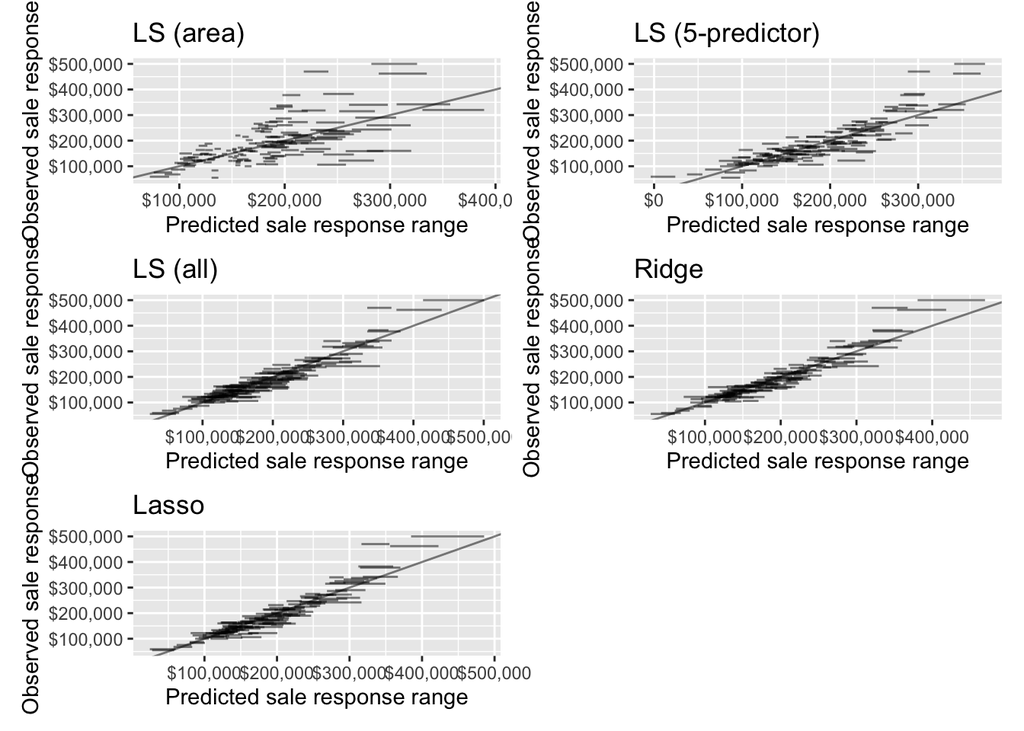

Figure 2: Prediction stability plots showing the range of predictions for 150 randomly selected validation set data point across the 100 different LS fits with (a) one predictive feature (area), (b) five predictive features, and (c) all available predictive features, each trained on a different perturbed version of the training dataset.

```r
set.seed(8674)
val_sample_pid <- sample(ames_val_preprocessed$pid, 150)


gg_stability_data_ls_area <- perturbed_data_pred |>
  filter(pid %in% val_sample_pid) |>
  predStabilityPlot(.true_var = true_val, .pred_var = pred_val_ls_area,
                    .title = "LS (area)")

gg_stability_data_ls_multi <- perturbed_data_pred |>
  filter(pid %in% val_sample_pid) |>
  predStabilityPlot(.true_var = true_val, .pred_var = pred_val_ls_multi,
                    .title = "LS (5-predictor)")

gg_stability_data_ls_all <- perturbed_data_pred |>
  filter(pid %in% val_sample_pid) |>
  predStabilityPlot(.true_var = true_val, .pred_var = pred_val_ls_all,
                    .title = "LS (all)")

gg_stability_data_ridge <- perturbed_data_pred |>
  filter(pid %in% val_sample_pid) |>
  predStabilityPlot(.true_var = true_val, .pred_var = pred_val_ridge,
                    .title = "Ridge")

gg_stability_data_lasso <- perturbed_data_pred |>
  filter(pid %in% val_sample_pid) |>
  predStabilityPlot(.true_var = true_val, .pred_var = pred_val_lasso,
                    .title = "Lasso")


gg_stability_data_ls_area + gg_stability_data_ls_multi +
  gg_stability_data_ls_all + gg_stability_data_ridge +
  gg_stability_data_lasso + plot_spacer() +
  plot_layout(ncol = 2)
```

It is clear that the range of predictions gets wider for the most complex fits with more predictive features (even though they are more accurate overall), but it looks like regularization helps increase the stability of these predictions slightly.

Let’s quantify the average sd of the predictions for each of the fits

```r
perturbed_data_pred |>
  # for each house
  group_by(pid) |>
  # compute the SD for each pid for each model
  summarise(sd_area = sd(pred_val_ls_area),
            sd_multi = sd(pred_val_ls_multi),
            sd_all = sd(pred_val_ls_all),
            sd_ridge = sd(pred_val_ridge),
            sd_lasso = sd(pred_val_lasso)) |>
  ungroup() |>
  # compute the average SD for each model across all pids
  summarise(mean_sd_area = mean(sd_area),
            mean_sd_multi = mean(sd_multi),
            mean_sd_all = mean(sd_all),
            mean_sd_ridge = mean(sd_ridge),
            mean_sd_lasso = mean(sd_lasso))
```

```
# A tibble: 1 × 5
  mean_sd_area mean_sd_multi mean_sd_all mean_sd_ridge mean_sd_lasso
         <dbl>         <dbl>       <dbl>         <dbl>         <dbl>
1        2169.         3591.       5827.         4383.         4594.
```

Lastly, we will look at the stability of the coefficients themselves. First let’s write a function for extracting the *coefficients* from the ridge and lasso fits:

```r
coefsRegularizedLs <- function(.data_train,
                               .alpha) {

  # standardize the training data
  x_train <- .data_train |>
    dplyr::select(-sale_price) |>
    mutate_all(~(. - mean(.)) / sd(.)) |>
    as.matrix()
  y_train <- .data_train |>
    pull(sale_price)

  # CV hyperparameter selection
  # compute cv.glment
  reg_cv <- cv.glmnet(x = x_train, y = y_train,
                      type.measure="mse", nfolds = 10,
                      alpha = .alpha)
  # compute the fit
  reg_fit <- glmnet(x = x_train, y = y_train,
                    lambda = reg_cv$lambda,
                    alpha = .alpha)

  coefs <- reg_fit$beta[, which(reg_cv$lambda == reg_cv$lambda.1se)]

  return(enframe(coefs,
                 name = "variable",
                 value = "coefficient"))
}
```

Then we will aggregate the coefficients for each fit together. However, to ensure that the ridge/lasso coefficients are comparable with the unregularized coefficients, we will re-fit each of the unregularized fits using the standardized data.

```r
standardize <- function(x) {
  (x - mean(x)) / sd(x)
}

perturbed_data_coefs <- ames_data_perturbed |>
  rowwise() |>
  # create a standardized version of each of the perturbed datasets
  mutate(data_train_perturbed_std = list(
    mutate(data_train_perturbed,
           across(where(is.numeric), standardize)))) |>
  # create a standardized version of each of the perturbed datasets (with
  #   categorical neighborhood variable)
  mutate(data_train_perturbed_nbhd_std = list(
    mutate(data_train_perturbed_nbhd,
           across(where(is.numeric), standardize)))) |>
  # compute the LS fits
  mutate(ls_all = list(lm(sale_price ~ .,
                          data_train_perturbed_std)),
         ls_multi = list(lm(sale_price ~ gr_liv_area + overall_qual +
                              year_built + bedroom_abv_gr + neighborhood,
                            data_train_perturbed_nbhd_std)),
         ls_area = list(lm(sale_price ~ gr_liv_area,
                           data_train_perturbed_std))) |>
  # extract the coefficients from each LS fit and the ridge and lasso fits
  mutate(coefs_ls_area = list(enframe(ls_area$coefficients,
                                      name = "variable",
                                      value = "coefficient")),
         coefs_ls_multi = list(enframe(ls_multi$coefficients,
                                       name = "variable",
                                       value = "coefficient")),
         coefs_ls_all = list(enframe(ls_all$coefficients,
                                     name = "variable",
                                     value = "coefficient")),
         coefs_ridge = list(coefsRegularizedLs(data_train_perturbed_std,
                                               .alpha = 0)),
         coefs_lasso = list(coefsRegularizedLs(data_train_perturbed_std,
                                               .alpha = 1))) |>
  # select just the coefficient columns
  select(coefs_ls_area, coefs_ls_multi, coefs_ls_all, coefs_ridge,
         coefs_lasso) |>
  # convert to longer form
  pivot_longer(everything(), names_to = "fit", values_to = "coefs",
               names_prefix = "coefs_") |>
  # unnest the list columns
  unnest(coefs)
# look at the object we created
perturbed_data_coefs
```

```
# A tibble: 15,900 × 3
   fit      variable            coefficient
   <chr>    <chr>                     <dbl>
 1 ls_area  (Intercept)           -1.11e-16
 2 ls_area  gr_liv_area            7.65e- 1
 3 ls_multi (Intercept)            4.83e- 2
 4 ls_multi gr_liv_area            5.30e- 1
 5 ls_multi overall_qual           4.07e- 1
 6 ls_multi year_built             1.98e- 1
 7 ls_multi bedroom_abv_gr        -1.26e- 1
 8 ls_multi neighborhoodCollgCr   -1.05e- 1
 9 ls_multi neighborhoodEdwards   -1.54e- 1
10 ls_multi neighborhoodGilbert   -3.47e- 1
# ℹ 15,890 more rows
```

Then we can visualize the top 20 coefficients (based on the LS (all predictors) fit)

```r
# identify the 20 variables with the largest coefficients
top_20_coefs_ls_all <- perturbed_data_coefs |>
  # filter to LS (all predictors) coefficients
  filter(fit == "ls_all") |>
  # for each variable
  group_by(variable) |>
  # compute the average perturbed coefficient value
  summarise(mean_coef = mean(coefficient)) |>
  # remove the intercept
  filter(variable != "(Intercept)") |>
  # arrange coefs in descending order
  arrange(desc(mean_coef)) |>
  # take the top 20
  head(20) |>
  # extract the variable names
  distinct(variable) |>
  pull(variable)
```

Then we can create a series of boxplots showing the distribution of each perturbed coefficient for each fit

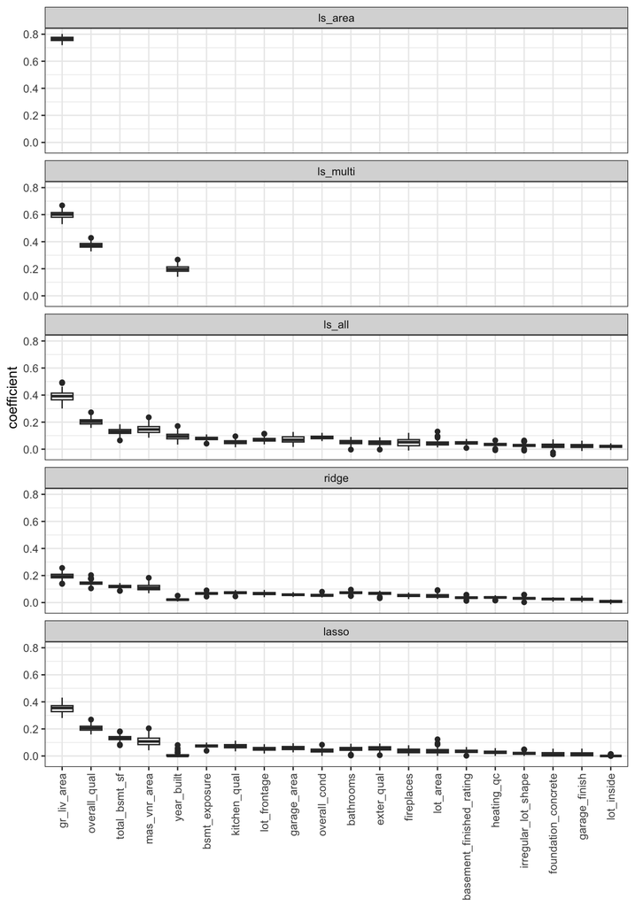

```r
# create a plot
perturbed_data_coefs |>
  filter(variable %in% top_20_coefs_ls_all) |>
  # make sure the fits appear in the correct order
  mutate(fit = fct_inorder(fit)) |>
  # force the variables to appear in descending order
  group_by(variable) |>
  mutate(mean_coef = abs(mean(coefficient))) |>
  ungroup() |>
  arrange(desc(mean_coef)) |>
  mutate(variable = fct_inorder(variable)) |>
  # create boxplots for the distribution of each coefficient
  ggplot() +
  geom_boxplot(aes(x = variable, y = coefficient)) +
  facet_wrap(~fit, ncol = 1) +
  theme_bw() +
  scale_x_discrete(NULL) +
  theme(axis.text.x = element_text(angle = 90,
                                   hjust = 1,
                                   vjust = 0.5))
```

#### Stability to cleaning/pre-processing judgment call perturbations

Next, we need to repeat this stability analysis, but instead of using data perturbations based on sampling and adding random noise, we will investigate perturbations to our cleaning and pre-processing judgment calls.

First, we need to identify all of the judgment calls that we plan to perturb. The judgment calls (and the options) that we will consider are:

- `max_identical_thresh`: Missing value threshold of 0.65, 0.8, or 0.95 (i.e., we remove variables whose proportion of missing values exceeds this value).
- `n_neighborhoods`: Keeping the 10 or 20 largest neighborhoods (and aggregate the rest before computing neighborhood dummy variables).
- `impute_missing_categorical`: Impute missing categorical values with either an “other” value or the mode.
- `simplify_vars`: Simplify several variables (such as bathrooms, porch, etc) or not.
- `transform_response`: Apply a log or square-root transformation to the response, or leave it untransformed.
- `cor_feature_selection_threshold`: Apply correlation feature selection with a threshold of 0.5, or not applying correlation feature selection (threshold of 0).
- `convert_categorical`: Convert categorical variables directly to a numeric variable or create (simplified) dummy variables.

Using `expand_grid()`, we can create a data frame where each row corresponds to a unique combination of these judgment call options:

```r
# create the judgment call perturbation combinations
param_options <- expand_grid(max_identical_thresh = c(0.65, 0.8, 0.95),
                             n_neighborhoods = c(10, 20),
                             impute_missing_categorical = c("other", "mode"),
                             simplify_vars = c(TRUE, FALSE),
                             transform_response = c("none", "log", "sqrt"),
                             cor_feature_selection_threshold = c(0, 0.5),
                             convert_categorical = c("numeric", "simplified_dummy", "dummy"))

param_options |> print(width = Inf)
```

```
# A tibble: 432 × 7
   max_identical_thresh n_neighborhoods impute_missing_categorical simplify_vars
                  <dbl>           <dbl> <chr>                      <lgl>
 1                 0.65              10 other                      TRUE
 2                 0.65              10 other                      TRUE
 3                 0.65              10 other                      TRUE
 4                 0.65              10 other                      TRUE
 5                 0.65              10 other                      TRUE
 6                 0.65              10 other                      TRUE
 7                 0.65              10 other                      TRUE
 8                 0.65              10 other                      TRUE
 9                 0.65              10 other                      TRUE
10                 0.65              10 other                      TRUE
   transform_response cor_feature_selection_threshold convert_categorical
   <chr>                                        <dbl> <chr>
 1 none                                           0   numeric
 2 none                                           0   simplified_dummy
 3 none                                           0   dummy
 4 none                                           0.5 numeric
 5 none                                           0.5 simplified_dummy
 6 none                                           0.5 dummy
 7 log                                            0   numeric
 8 log                                            0   simplified_dummy
 9 log                                            0   dummy
10 log                                            0.5 numeric
# ℹ 422 more rows
```

Then we need to create a cleaned/pre-processed version of the training and validation datasets for each combination of these judgment calls by adding list columns to the `param_options` tibble:

```r
# create the perturbed datasets in a list column
ames_jc_perturbed <- param_options |>
  rowwise() |>
  # add training data list column
  mutate(data_train_perturbed =
           list(preProcessAmesData(ames_train_clean,
                                   max_identical_thresh = max_identical_thresh,
                                   n_neighborhoods = n_neighborhoods,
                                   impute_missing_categorical = impute_missing_categorical,
                                   simplify_vars = simplify_vars,
                                   transform_response = transform_response,
                                   cor_feature_selection_threshold = cor_feature_selection_threshold,
                                   convert_categorical = convert_categorical))) |>
  # add validation data list column
  mutate(data_val_perturbed =
           list(preProcessAmesData(ames_val_clean,
                                   max_identical_thresh = max_identical_thresh,
                                   n_neighborhoods = n_neighborhoods,
                                   # make sure the validation neighborhoods match the training neighborhoods
                                   neighborhood_levels = map_chr(str_split(colnames(select(data_train_perturbed, contains("neighborhood"))), "neighborhood_"), ~.[2]),
                                   impute_missing_categorical = impute_missing_categorical,
                                   simplify_vars = simplify_vars,
                                   transform_response = transform_response,
                                   cor_feature_selection_threshold = cor_feature_selection_threshold,
                                   convert_categorical = convert_categorical,
                                   # make sure validation set cols match the training set cols
                                   column_selection = colnames(data_train_perturbed),
                                   keep_pid = TRUE)))

# look at the object we just created
ames_jc_perturbed |> print(width = Inf)
```

```
# A tibble: 432 × 9
# Rowwise:
   max_identical_thresh n_neighborhoods impute_missing_categorical simplify_vars
                  <dbl>           <dbl> <chr>                      <lgl>
 1                 0.65              10 other                      TRUE
 2                 0.65              10 other                      TRUE
 3                 0.65              10 other                      TRUE
 4                 0.65              10 other                      TRUE
 5                 0.65              10 other                      TRUE
 6                 0.65              10 other                      TRUE
 7                 0.65              10 other                      TRUE
 8                 0.65              10 other                      TRUE
 9                 0.65              10 other                      TRUE
10                 0.65              10 other                      TRUE
   transform_response cor_feature_selection_threshold convert_categorical
```

[output cut: 24 more lines]

Then we can essentially repeat the code from above, but for these judgment call-perturbed datasets. However, since the judgment calls primarily don’t affect the single-predictor and 5-predictor fits, we will just focus on the LS (all predictor) fit and the lasso and ridge regularized fits.

```r
perturbed_jc_pred <- ames_jc_perturbed |>
  rowwise() |>
  # generate the LS (all) fit
  mutate(ls_all = list(lm(sale_price ~ ., data_train_perturbed))) |>
  mutate(pid = list(data_val_perturbed$pid),
         true_val = list(data_val_perturbed$sale_price),
         pred_val_ls_all = list(predict(ls_all, data_val_perturbed)),
         pred_val_ridge = list(predRegularizedLs(data_train_perturbed,
                                                 data_val_perturbed,
                                                 .alpha = 0)),
         pred_val_lasso = list(predRegularizedLs(data_train_perturbed,
                                                 data_val_perturbed,
                                                 .alpha = 1))) |>
  # if the perturbation involved a response transformation, we need to undo
  # the transformation for the predictions so that they are comparable with
  # the untransformed versions
  mutate(pred_val_ls_all =
           case_when(transform_response == "log" ~ list(exp(pred_val_ls_all)),
                     transform_response == "sqrt" ~ list(pred_val_ls_all^2),
                     transform_response == "none" ~ list(pred_val_ls_all))) |>
  mutate(pred_val_ridge =
           case_when(transform_response == "log" ~ list(exp(pred_val_ridge)),
                     transform_response == "sqrt" ~ list(pred_val_ridge^2),
                     transform_response == "none" ~ list(pred_val_ridge))) |>
  mutate(pred_val_lasso =
           case_when(transform_response == "log" ~ list(exp(pred_val_lasso)),
                     transform_response == "sqrt" ~ list(pred_val_lasso^2),
                     transform_response == "none" ~ list(pred_val_lasso))) |>
  mutate(true_val =
           case_when(transform_response == "log" ~ list(exp(true_val)),
                     transform_response == "sqrt" ~ list(true_val^2),
                     transform_response == "none" ~ list(true_val))) |>
  # remove columns we won't need anymore
  select(-ls_all, -data_train_perturbed, -data_val_perturbed) |>
  ungroup() |>
  # unnest the tibble
  unnest(c(pid, true_val,
           pred_val_ls_all, pred_val_ridge, pred_val_lasso))

# look at the object we've created
perturbed_jc_pred |> print(width = Inf)
```

```
# A tibble: 274,752 × 12
   max_identical_thresh n_neighborhoods impute_missing_categorical simplify_vars
                  <dbl>           <dbl> <chr>                      <lgl>
 1                 0.65              10 other                      TRUE
 2                 0.65              10 other                      TRUE
 3                 0.65              10 other                      TRUE
 4                 0.65              10 other                      TRUE
 5                 0.65              10 other                      TRUE
 6                 0.65              10 other                      TRUE
 7                 0.65              10 other                      TRUE
 8                 0.65              10 other                      TRUE
 9                 0.65              10 other                      TRUE
10                 0.65              10 other                      TRUE
   transform_response cor_feature_selection_threshold convert_categorical
   <chr>                                        <dbl> <chr>
```

[output cut: 23 more lines]

We next want to use it to visualize the range of perturbed predictions for 150 validation set houses for each fit. However, first, we should filter any particularly poorly performing fits. To identify whether there are any particularly poorly performing fits, let’s compute the correlation predictive performance for each fit to each perturbed dataset and visualize their distributions across the different fits and judgment calls.

```r
perturbed_jc_correlations <- perturbed_jc_pred |>
  # convert the data to long-form (create a single column for all predictions and
  # a fit/model identifier)
  pivot_longer(cols = c("pred_val_ls_all", "pred_val_ridge", "pred_val_lasso"),
                names_to = "fit", values_to = "pred_val",
               names_prefix = "pred_val_") |>
  group_by(fit, max_identical_thresh, n_neighborhoods,
                      simplify_vars, convert_categorical, transform_response,
                       cor_feature_selection_threshold) |>
  # compute the correlation performance for each fit
  summarise(correlation = cor(true_val, pred_val))
```

[output not shown]

```r
# look at the object
perturbed_jc_correlations |> print(width = Inf)
```

```
# A tibble: 648 × 8
# Groups:   fit, max_identical_thresh, n_neighborhoods, simplify_vars,
#   convert_categorical, transform_response [324]
   fit   max_identical_thresh n_neighborhoods simplify_vars convert_categorical
   <chr>                <dbl>           <dbl> <lgl>         <chr>
 1 lasso                 0.65              10 FALSE         dummy
 2 lasso                 0.65              10 FALSE         dummy
 3 lasso                 0.65              10 FALSE         dummy
 4 lasso                 0.65              10 FALSE         dummy
 5 lasso                 0.65              10 FALSE         dummy
 6 lasso                 0.65              10 FALSE         dummy
 7 lasso                 0.65              10 FALSE         numeric
 8 lasso                 0.65              10 FALSE         numeric
 9 lasso                 0.65              10 FALSE         numeric
10 lasso                 0.65              10 FALSE         numeric
   transform_response cor_feature_selection_threshold correlation
   <chr>                                        <dbl>       <dbl>
 1 log                                            0         0.963
 2 log                                            0.5       0.947
 3 none                                           0         0.949
 4 none                                           0.5       0.912
 5 sqrt                                           0         0.960
 6 sqrt                                           0.5       0.936
 7 log                                            0         0.963
 8 log                                            0.5       0.950
 9 none                                           0         0.942
10 none                                           0.5       0.923
# ℹ 638 more rows
```

Let’s visualize these correlations against each of the judgment call options for each fit:

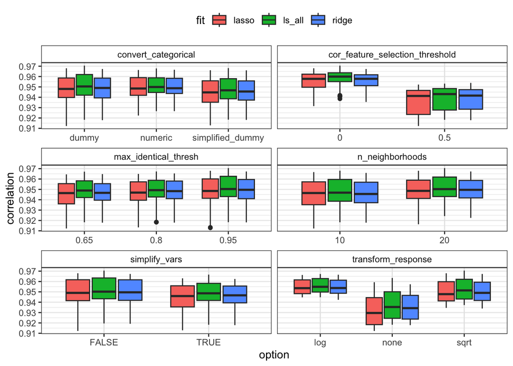

Figure 4: Boxplots demonstrating the distributions of the LS, lasso, and ridge validation set correlation performance, where each algorithm is fit using various combinations of the following six pre-processing judgment calls: (a) converting ordered categorical variables to dummy variables, numeric variables, or a simplified version of the dummy variables, (b) the choice of missing value threshold above which to remove features, (c) the choice of how many neighborhoods to aggregate, (d) whether to simplify several variables, (e) whether to apply a log or square-root transformation to the response, and (f) whether to apply a correlation-based feature selection (a threshold of 0 corresponds to no feature selection).

```r
perturbed_jc_correlations |>
  ungroup() |>
  # convert all judgment call options to character variables
  mutate(across(one_of("max_identical_thresh", "n_neighborhoods",
                       "simplify_vars", "convert_categorical",
                       "transform_response",
                       "cor_feature_selection_threshold"), as.character)) |>
  # create a long-form data frame with a single column for the judgment calls
  pivot_longer(cols = c("max_identical_thresh", "n_neighborhoods",
                        "simplify_vars", "convert_categorical",
                        "transform_response",
                        "cor_feature_selection_threshold"),
               names_to = "judgment_call", values_to = "option") |>
  # plot the correlations against the judgment call options for each fit
  ggplot() +
  theme_bw() +
  geom_boxplot(aes(x = option, y = correlation, fill = fit)) +
  facet_wrap(~judgment_call, scales = "free_x", ncol = 2) +
  theme(legend.position = "top",
        panel.grid.major.x = element_line(color = "grey90"),
        strip.background = element_rect(fill = "white"))
```

The main takeaway is that transforming the response dramatically improves the predictive performance, and applying correlation feature selection dramatically diminishes it. Based on this figure, **let’s use a predictability screening test that requires each fit has at least a validation set correlation performance of 0.93**.

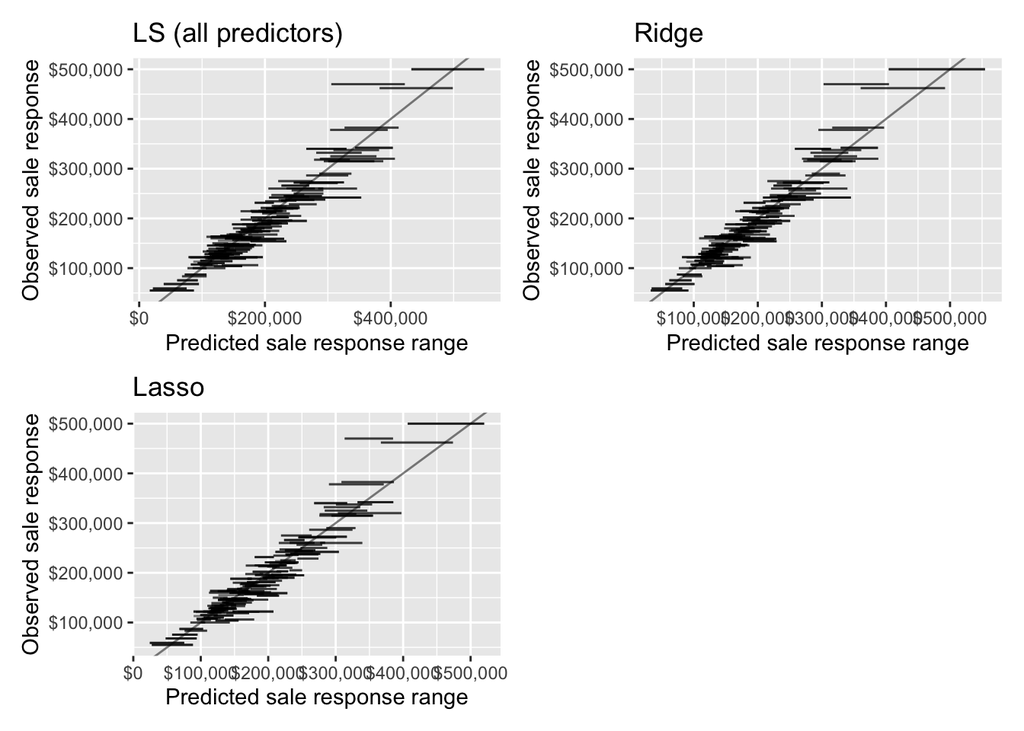

```r
gg_stability_jc_ls_all <- perturbed_jc_pred |>
  # conduct predictability screening
  left_join(filter(perturbed_jc_correlations, fit == "ls_all")) |>
  select(-fit) |>
  filter(correlation > 0.93) |>
  # filter to the 150 validation set houses
  filter(pid %in% val_sample_pid) |>
  # create the prediction stability plot
  predStabilityPlot(.true_var = true_val,
                    .pred_var = pred_val_ls_all,
                    .title = "LS (all predictors)")

gg_stability_jc_ridge <- perturbed_jc_pred |>
  # conduct predictability screening
  left_join(filter(perturbed_jc_correlations, fit == "ridge")) |>
  select(-fit) |>
  filter(correlation > 0.93) |>
  # filter to the 150 validation set houses
  filter(pid %in% val_sample_pid) |>
  # create the prediction stability plot
  predStabilityPlot(.true_var = true_val,
                    .pred_var = pred_val_ridge,
                    .title = "Ridge")

gg_stability_jc_lasso <- perturbed_jc_pred |>
  # conduct predictability screening
  left_join(filter(perturbed_jc_correlations, fit == "lasso")) |>
  select(-fit) |>
  filter(correlation > 0.93) |>
  # filter to the 150 validation set houses
  filter(pid %in% val_sample_pid) |>
  # create the prediction stability plot
  predStabilityPlot(.true_var = true_val,
                    .pred_var = pred_val_lasso,
                    .title = "Lasso")

gg_stability_jc_ls_all + gg_stability_jc_ridge +
  gg_stability_jc_lasso + plot_spacer() +
  plot_layout(ncol = 2)
```

The three plots look fairly similar, but we can compute the average observation-specific SD of the predictions for each fit (that passed the predictability screening) to compare.

```r
perturbed_jc_pred |>
  pivot_longer(c("pred_val_ls_all", "pred_val_ridge", "pred_val_lasso"),
               names_to = "fit", values_to = "pred_val",
               names_prefix = "pred_val_") |>
  # conduct predictability screening
  left_join(perturbed_jc_correlations) |>
  filter(correlation > 0.93) |>
  # for each house
  group_by(pid, fit) |>
  # compute the sd of each set of perturbed predictions for each house
  summarise(sd = sd(pred_val)) |>
  ungroup() |>
  group_by(fit) |>
  summarise(mean_sd = mean(sd))
```

[output not shown]

```
# A tibble: 3 × 2
  fit    mean_sd
  <chr>    <dbl>
1 lasso    7314.
2 ls_all   8831.
3 ridge    7973.
```

From the table above, it again seems that the regularization helps improve the stability of the predictions to judgment call perturbations, since the average observation-specific SD of the predictions are smaller for the `lasso` and `ridge` fits than for the unregularized (`ls_all`) fit.

Lastly, we will again look at the stability of the coefficients themselves.

Again, to ensure that the ridge/lasso coefficients are comparable with the unregularized coefficients, we will re-fit each of the unregularized fits using the standardized data.

```r
perturbed_jc_coefs <- ames_jc_perturbed |>
  rowwise() |>
  # create a standardized version of each of the perturbed datasets
  mutate(data_train_perturbed_std = list(
    mutate(data_train_perturbed,
           across(where(is.numeric), standardize)))) |>
  # compute the LS fits
  mutate(ls_all = list(lm(sale_price ~ .,
                          data_train_perturbed_std))) |>
  # extract the coefficients from each LS fit and the ridge and lasso fits
  mutate(coefs_ls_all = list(enframe(ls_all$coefficients,
                                     name = "variable",
                                     value = "coefficient")),
         coefs_ridge = list(coefsRegularizedLs(data_train_perturbed_std,
                                               .alpha = 0)),
         coefs_lasso = list(coefsRegularizedLs(data_train_perturbed_std,
                                               .alpha = 1))) |>
  # select just the coefficient columns
  select(coefs_ls_all, coefs_ridge, coefs_lasso) |>
  # convert to longer form
  pivot_longer(everything(), names_to = "fit", values_to = "coefs",
               names_prefix = "coefs_") |>
  # unnest the list columns
  unnest(coefs)
# look at the object we created
perturbed_jc_coefs
```

```
# A tibble: 56,880 × 3
   fit    variable        coefficient
   <chr>  <chr>                 <dbl>
 1 ls_all (Intercept)        2.15e-16
 2 ls_all overall_qual       2.01e- 1
 3 ls_all gr_liv_area        4.66e- 1
 4 ls_all bathrooms          3.96e- 2
 5 ls_all kitchen_qual       6.40e- 2
 6 ls_all total_bsmt_sf      1.32e- 1
 7 ls_all garage_cars       -8.29e- 3
 8 ls_all garage_area        7.62e- 2
 9 ls_all tot_rms_abv_grd   -1.95e- 2
10 ls_all bsmt_qual         -2.23e- 2
# ℹ 56,870 more rows
```

Then we can visualize the top 20 coefficients (based on the LS (all predictors) fit)

```r
# identify the 20 variables with the largest coefficients
top_20_coefs_ls_all_jc <- perturbed_jc_coefs |>
  # filter to LS (all predictors) coefficients
  filter(fit == "ls_all") |>
  # for each variable
  group_by(variable) |>
  # compute the average perturbed coefficient value
  summarise(mean_coef = mean(coefficient)) |>
  # remove the intercept
  filter(variable != "(Intercept)") |>
  # arrange coefs in descending order
  arrange(desc(mean_coef)) |>
  # take the top 20
  head(20) |>
  # extract the variable names
  distinct(variable) |>
  pull(variable)
```

Then we can create a series of boxplots showing the distribution of each perturbed coefficient for each fit

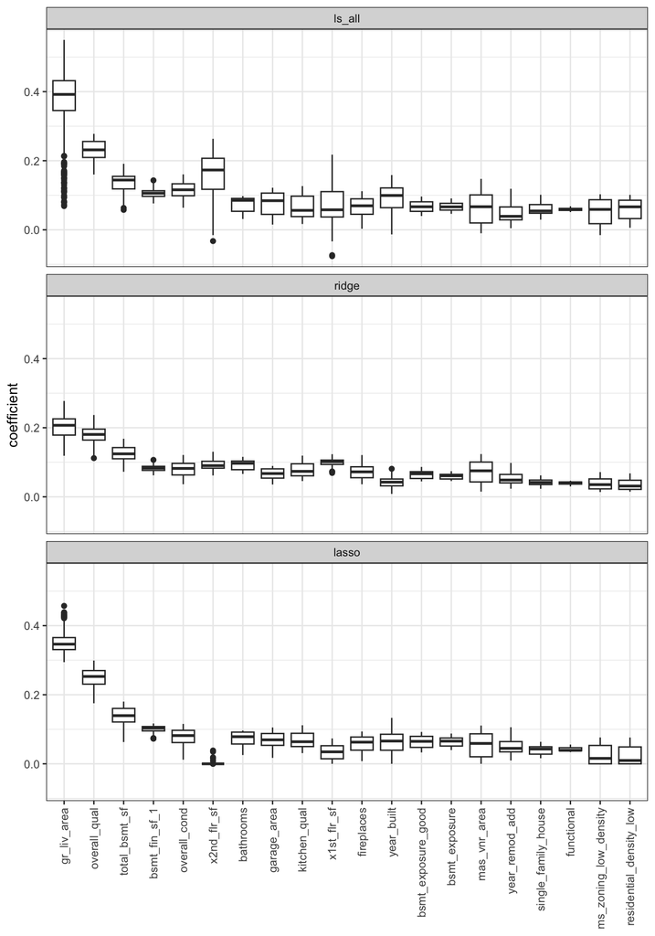

```r
# create a plot
perturbed_jc_coefs |>
  filter(variable %in% top_20_coefs_ls_all_jc) |>
  # make sure the fits appear in the correct order
  mutate(fit = fct_inorder(fit)) |>
  # force the variables to appear in descending order
  group_by(variable) |>
  mutate(mean_coef = abs(mean(coefficient))) |>
  ungroup() |>
  arrange(desc(mean_coef)) |>
  mutate(variable = fct_inorder(variable)) |>
  # create boxplots for the distribution of each coefficient
  ggplot() +
  geom_boxplot(aes(x = variable, y = coefficient)) +
  facet_wrap(~fit, ncol = 1) +
  theme_bw() +
  scale_x_discrete(NULL) +
  theme(axis.text.x = element_text(angle = 90,
                                   hjust = 1,
                                   vjust = 0.5))
```